# Optimal Resource Allocation

Timothy Wong

17/07/2020

## Objectives

We want to allocate resources to zones while minimising the total cost (e.g. travel time, travel distance, expenditure, etc.) for the entire system.

## Allocation Costs

```r
I <- 10
J <- 5

my_costs <- matrix(runif(I*J), nrow = I, ncol = J)
rownames(my_costs) <- sprintf("R_%s", seq.int(from = 1,length.out = I))
colnames(my_costs) <- sprintf("Z_%s", seq.int(from = 1,length.out = J))

my_costs
```

```
##             Z_1        Z_2       Z_3       Z_4        Z_5
## R_1  0.31300760 0.13139723 0.4963993 0.7840266 0.73679765
## R_2  0.53842965 0.87764273 0.7447344 0.0672037 0.91149671
## R_3  0.25143509 0.90748595 0.1146217 0.5751526 0.53631711
## R_4  0.95993728 0.36790132 0.2225167 0.2831948 0.01454969
## R_5  0.30849284 0.74401005 0.9107487 0.3551488 0.52337242
## R_6  0.39425429 0.40168052 0.3757401 0.3075921 0.11172232
## R_7  0.04196323 0.07738462 0.7931153 0.5933098 0.76521537
## R_8  0.72600738 0.46235135 0.4789284 0.8689144 0.18859216
## R_9  0.68708525 0.88440675 0.7547065 0.2911243 0.36670425
## R_10 0.99598999 0.31697881 0.8720274 0.6002004 0.48280044
```

This system has $I=10$ resources and $J=5$ zones, so that the resources are denoted as $\{R_1, R_2, R_3...R_I\}$ while the zones are denoted as $\{Z_1, Z_2, Z_3...Z_J\}$.

A $I \times J$ matrix denoted as $c$ represents the allocation cost for each resource to each zone. The value $c_{i,j}$ represents the cost of assigning resource $R_i$ to zone $Z_j$.

In this example, in order to assign resource $R_2$ to zone $Z_3$, a cost of $c_{2,3}=0.745$ is incurred.

## Minimum Capacity

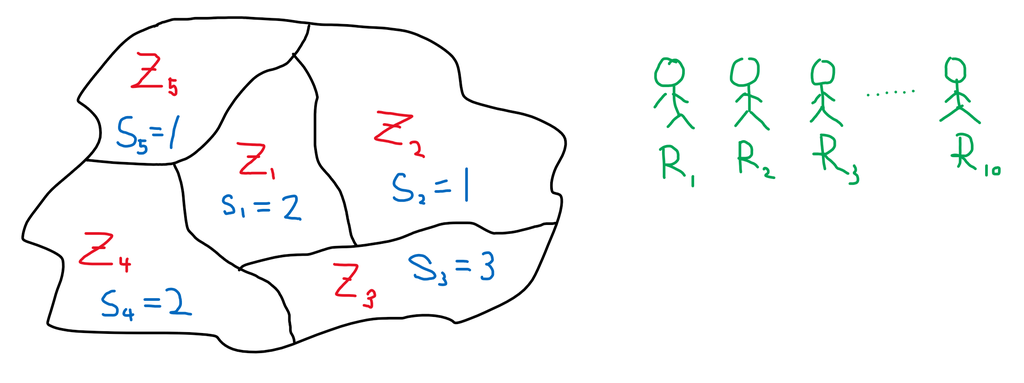

Map showing layout of the zones

```r
s <- c(2, 1, 3, 2, 1)
```

A integer vector $s$ of length $J$ will specify the minimum number of resources required for each zone. In this example, $s_1=2$ means that zone $Z_1$ requires at least 2 resources.

## Problem Formulation

The Integer Programming (IP) problem is formulated as below.

The symbol $x$ denotes allocation matrix of size $I \times J$, which is made up of binary values. When $x_{ij}=1$, it indicates resource $R_i$ is allocated to zone $Z_j$.

The constrains also specify that any resources can only be allocated to exactly $1$ zone, and the total number of resources allocated to zone $Z_j$ must equal to or exceeding the threshold value indicated by $s_j$.

The objective function is a function which minimises the total cost $z$ of the system.

$$\begin{aligned}
& \text{Let} & I & = \text{No. of resources} \\
& & J & = \text{No. of zones} \\
& & x & = \text{Allocation matrix} \\
& & c & = \text{Cost matrix} \\
& & s & = \text{Minimum no. of resources} \\
\end{aligned}
\\
\\
\begin{aligned}
& \text{Minimise} & z & = \sum_{i=1}^{I}\sum_{j=1}^{J}x_{ij}c_{ij} \\
& \text{Subject to} & x_{ij} & \in \{{0,1\}} & \forall &i &=1,2,3,...,I \\
&&&&& j &=1,2,3,...,J \\
& & \sum_{j=1}^{J}x_{ij} & = 1 & \forall &i &=1,2,3,...,I \\
& & \sum_{i=1}^{I}x_{ij} & \geq s_{j} & \forall &j &=1,2,3,...,J
\end{aligned}$$

## Problem Solving

To solve the IP problem, load the following packages in `R`. We will solve this problem using the simplex algorithm.

```r
library(dplyr)
library(ROI)
library(ROI.plugin.glpk)
library(ompr)
library(ompr.roi)
```

The IP problem is expressed in `R` in the following code chunk. The computation time is usually significantly longer in a complex, real-world problem.

```r
cost_func <- function(i,j){
  vapply(seq_along(i), function(k) my_costs[i[k], j[k]], numeric(1L))
}

model <- MILPModel() %>%
  add_variable(x[i, j], i = 1:I, j = 1:J, type = "binary") %>%
  add_constraint(sum_expr(x[i, j], j = 1:J) == 1, i = 1:I) %>%
  add_constraint(sum_expr(x[i, j], i = 1:I) >= s[j], j = 1:J) %>%
  set_objective(sum_expr(x[i, j] * colwise(cost_func(i,j)), i = 1:I, j = 1:J), sense = "min")

my_solution <-  model %>%
  solve_model(with_ROI("glpk", verbose = TRUE))
```

```
## <SOLVER MSG>  ----
## GLPK Simplex Optimizer, v4.47
## 15 rows, 50 columns, 100 non-zeros
##       0: obj =  0.000000000e+000  infeas = 1.900e+001 (10)
## *    24: obj =  5.697057522e+000  infeas = 0.000e+000 (1)
## *    45: obj =  2.058630769e+000  infeas = 0.000e+000 (0)
## OPTIMAL SOLUTION FOUND
## GLPK Integer Optimizer, v4.47
## 15 rows, 50 columns, 100 non-zeros
## 50 integer variables, all of which are binary
## Integer optimization begins...
## +    45: mip =     not found yet >=              -inf        (1; 0)
## +    45: >>>>>  2.058630769e+000 >=  2.058630769e+000   0.0% (1; 0)
## +    45: mip =  2.058630769e+000 >=     tree is empty   0.0% (0; 1)
## INTEGER OPTIMAL SOLUTION FOUND
## <!SOLVER MSG> ----
```

Extracting the variable $x_{i,j}$ will return the optimal allocation results.

```r
my_allocation_results <- my_solution %>%
  get_solution(x[i,j]) %>%
  as_tibble() %>%
  filter(value == 1) %>%
  select(i, j) %>%
  arrange(i)

my_allocation_results
```

```
## # A tibble: 10 x 2
##        i     j
##    <int> <int>
##  1     1     2
##  2     2     4
##  3     3     3
##  4     4     3
##  5     5     1
##  6     6     3
##  7     7     1
##  8     8     5
##  9     9     4
## 10    10     2
```

## Verifying the Solution

We can count the number of resources allocated to each zone, which is indicated in column `n` below. Compare that with the target threshold column `s`.

```r
my_allocation_results %>%
  group_by(j) %>%
  count() %>%
  ungroup() %>%
  arrange(j) %>%
  bind_cols(s = s)
```

```
## # A tibble: 5 x 3
##       j     n     s
##   <int> <int> <dbl>
## 1     1     2     2
## 2     2     2     1
## 3     3     3     3
## 4     4     2     2
## 5     5     1     1
```